# External settlement and financial dynamics across the ready closures

Published

October 1, 2026

**Written:** 2026-10-01 · **Starting repo:** `main @ 80094f9`.

## What the comparison establishes

An arm is one runnable row of `data/arms.csv`. Z1/Z2 mean EU/RoW on the canonical workbook and North/South on the alternative workbook. All displayed numerical tables and the figure are recomputed from the named input CSVs when this report renders.

## Monetary hierarchy and the settlement mechanism

`reserve_spec` identifies which central bank can hold the other region’s bills; membership and monetary hierarchy are separate choices. Under gold settlement its directional label has no active reserve-bill role. Under fiat it identifies the reserve holder; under OPENFIXG that holder’s government adjusts. This implements the mechanisms discussed in Godley–Lavoie chapter 12 as documented in `log/trackers/closure_region.md` and `qmd/equations/closure_overrides.csv`.

Source: data/arms.csv, the eight arms present in the impulse CSV; registry values, not inferred from membership.

|  | arm | initial_state | closure_spec | reserve_spec |
| --- | --- | --- | --- | --- |
| 11 | revised | canonical_initial_state.xlsx | openfix_gold | z1_holds_z2 |
| 17 | revised_openfix_fiat | canonical_initial_state.xlsx | openfix_fiat | z1_holds_z2 |
| 13 | revised_ns | canonical_initial_state_North_South.xlsx | openfix_gold | z2_holds_z1 |
| 14 | revised_ns_openfix_fiat | canonical_initial_state_North_South.xlsx | openfix_fiat | z2_holds_z1 |
| 20 | revised_openfixg | canonical_initial_state.xlsx | openfixg | z1_holds_z2 |
| 19 | revised_quasifloat | canonical_initial_state.xlsx | quasifloat | z1_holds_z2 |
| 15 | revised_ns_openfixg | canonical_initial_state_North_South.xlsx | openfixg | z2_holds_z1 |
| 16 | revised_ns_quasifloat | canonical_initial_state_North_South.xlsx | quasifloat | z2_holds_z1 |

| Closure | What absorbs imbalance | Equation-based root expectation | Variable carrying a scenario’s external effect |
| --- | --- | --- | --- |
| OPENFIX-gold | Central-bank gold, fixed exchange rate | Debt/gold level directions can retain a unit root | Gold and cumulative public-debt changes |
| OPENFIX-fiat | Reserve holder’s foreign bills, gold fixed | The isolated reserve-interest recursion has multiplier $1+r_b$ | Foreign-bill reserves and their interest circuit |
| OPENFIXG | Reserve holder’s real government spending | Feedback is expected to remove the accumulating external mode; other roots remain to be measured | Adjusting government’s spending |
| Quasi-float | Exchange rate reacts to lagged current account; gold still settles | Depends on `par_xr` and the trade/financial feedback | Exchange rate, with residual gold/debt effects |

These are mechanism predictions from `model/code/MVP_model_2026.R`, not measured eigenvalues. For fiat, $R_{t+1}=(1+r_b)R_t+f_t$ describes the isolated reserve-interest circuit; an endogenous $f_t$ can change the coupled system’s root. OPENFIXG’s expected stabilisation must likewise be checked on the full system rather than inferred from a stationary cache.

## Measured baselines

The fiat file supersedes earlier fiat rows. Debt/VA is outstanding government bills divided by nominal value added in the same region’s currency. CAB/VA is the current-account flow divided by that same value added. The slope is OLS of debt/VA on period over the final baseline window, as defined in `R/closures/closure_baseline_stability.R`. Gold is quantity; foreign reserves are bills in the issuer’s currency. NA means the mirror reserve row does not exist, not zero holdings.

Basis: t=100 levels/ratios; debt/VA slope per period, OLS t=71..100. Source column names the input under output/calibration/.

|  | arm | region | debt_va_t100 | debt_va_slope | cab_va_t100 | xr_t100 | source |
| --- | --- | --- | --- | --- | --- | --- | --- |
| 1 | revised | Z1 | 0.808538 | -1.7e-05 | -3.8e-05 | 1.000000 | closure_baselines_stability_20260930_canonical.csv |
| 2 | revised | Z2 | 0.851106 | 4.1e-05 | 1.0e-05 | 1.000000 | closure_baselines_stability_20260930_canonical.csv |
| 17 | revised_openfix_fiat | Z1 | 0.809751 | -7.0e-06 | -5.9e-05 | 1.000000 | closure_baselines_stability_20261001_fiat.csv |
| 18 | revised_openfix_fiat | Z2 | 0.850021 | 3.8e-05 | 1.6e-05 | 1.000000 | closure_baselines_stability_20261001_fiat.csv |
| 9 | revised_ns | Z1 | 0.977821 | -1.0e-06 | 9.0e-06 | 1.000000 | closure_baselines_stability_20261001_ns.csv |
| 10 | revised_ns | Z2 | 0.364661 | 1.7e-05 | -1.9e-05 | 1.000000 | closure_baselines_stability_20261001_ns.csv |
| 19 | revised_ns_openfix_fiat | Z1 | 0.978733 | 7.0e-06 | 0.0e+00 | 1.000000 | closure_baselines_stability_20261001_fiat.csv |
| 20 | revised_ns_openfix_fiat | Z2 | 0.362900 | 0.0e+00 | 0.0e+00 | 1.000000 | closure_baselines_stability_20261001_fiat.csv |
| 7 | revised_openfixg | Z1 | 0.835476 | -7.7e-05 | -9.0e-06 | 1.000000 | closure_baselines_stability_20260930_canonical.csv |
| 8 | revised_openfixg | Z2 | 0.843824 | 4.4e-05 | 2.0e-06 | 1.000000 | closure_baselines_stability_20260930_canonical.csv |
| 5 | revised_quasifloat | Z1 | 0.804415 | -6.5e-05 | 8.0e-06 | 1.004389 | closure_baselines_stability_20260930_canonical.csv |
| 6 | revised_quasifloat | Z2 | 0.852227 | 5.4e-05 | -2.0e-06 | 0.995630 | closure_baselines_stability_20260930_canonical.csv |
| 13 | revised_ns_openfixg | Z1 | 0.983387 | 8.0e-06 | 0.0e+00 | 1.000000 | closure_baselines_stability_20261001_ns.csv |
| 14 | revised_ns_openfixg | Z2 | 0.352942 | 1.2e-05 | 0.0e+00 | 1.000000 | closure_baselines_stability_20261001_ns.csv |
| 15 | revised_ns_quasifloat | Z1 | 0.977827 | -1.0e-06 | 9.0e-06 | 1.000236 | closure_baselines_stability_20261001_ns.csv |
| 16 | revised_ns_quasifloat | Z2 | 0.364692 | 1.7e-05 | -1.8e-05 | 0.999764 | closure_baselines_stability_20261001_ns.csv |

Basis: baseline t=100 real government spending, gold quantity and foreign bills; source as above.

|  | arm | region | g_t100 | gold_t100 | fx_res_t100 | source |
| --- | --- | --- | --- | --- | --- | --- |
| 1 | revised | Z1 | 240.0000 | 2103.4139 | 0.00000 | closure_baselines_stability_20260930_canonical.csv |
| 2 | revised | Z2 | 675.0000 | 1896.5850 | NA | closure_baselines_stability_20260930_canonical.csv |
| 17 | revised_openfix_fiat | Z1 | 240.0000 | 2047.9065 | 20.59135 | closure_baselines_stability_20261001_fiat.csv |
| 18 | revised_openfix_fiat | Z2 | 675.0000 | 1952.0925 | NA | closure_baselines_stability_20261001_fiat.csv |
| 9 | revised_ns | Z1 | 626.8396 | 633.9695 | 0.00000 | closure_baselines_stability_20261001_ns.csv |
| 10 | revised_ns | Z2 | 287.9481 | 3366.0297 | 0.00000 | closure_baselines_stability_20261001_ns.csv |
| 19 | revised_ns_openfix_fiat | Z1 | 626.8396 | 600.3989 | 0.00000 | closure_baselines_stability_20261001_fiat.csv |
| 20 | revised_ns_openfix_fiat | Z2 | 287.9481 | 3399.6003 | -11.48542 | closure_baselines_stability_20261001_fiat.csv |
| 7 | revised_openfixg | Z1 | 239.9050 | 2074.7397 | 0.00000 | closure_baselines_stability_20260930_canonical.csv |
| 8 | revised_openfixg | Z2 | 675.0000 | 1925.2593 | NA | closure_baselines_stability_20260930_canonical.csv |
| 5 | revised_quasifloat | Z1 | 240.0000 | 2107.0739 | 0.00000 | closure_baselines_stability_20260930_canonical.csv |
| 6 | revised_quasifloat | Z2 | 675.0000 | 1892.9250 | NA | closure_baselines_stability_20260930_canonical.csv |
| 13 | revised_ns_openfixg | Z1 | 626.8396 | 615.9249 | 0.00000 | closure_baselines_stability_20261001_ns.csv |
| 14 | revised_ns_openfixg | Z2 | 287.8252 | 3384.0744 | 0.00000 | closure_baselines_stability_20261001_ns.csv |
| 15 | revised_ns_quasifloat | Z1 | 626.8396 | 633.8905 | 0.00000 | closure_baselines_stability_20261001_ns.csv |
| 16 | revised_ns_quasifloat | Z2 | 287.9481 | 3366.1087 | 0.00000 | closure_baselines_stability_20261001_ns.csv |

The negative South foreign-bill reserve is a short position. Stationarity does not make that position economically acceptable; acceptance or a second calibration instrument remains the maintainer’s decision.

## The one-period export impulse

`R/closures/impulse_closure.R` switches 10% of each Z2 household consumption share in its own-origin good to the corresponding Z1-origin good in period 70 only. Each industry’s total share is preserved; this is a change of origin, not a rise in household expenditure. Period 71 restores the original exogenous shares. The impulse CSV covers periods 68 through 100, and the pre-shock rows have zero differences for every arm. The figure includes both regions of every ready cell; exchange rate is Z1_xr in both region records, intentionally duplicated by the measurement script.

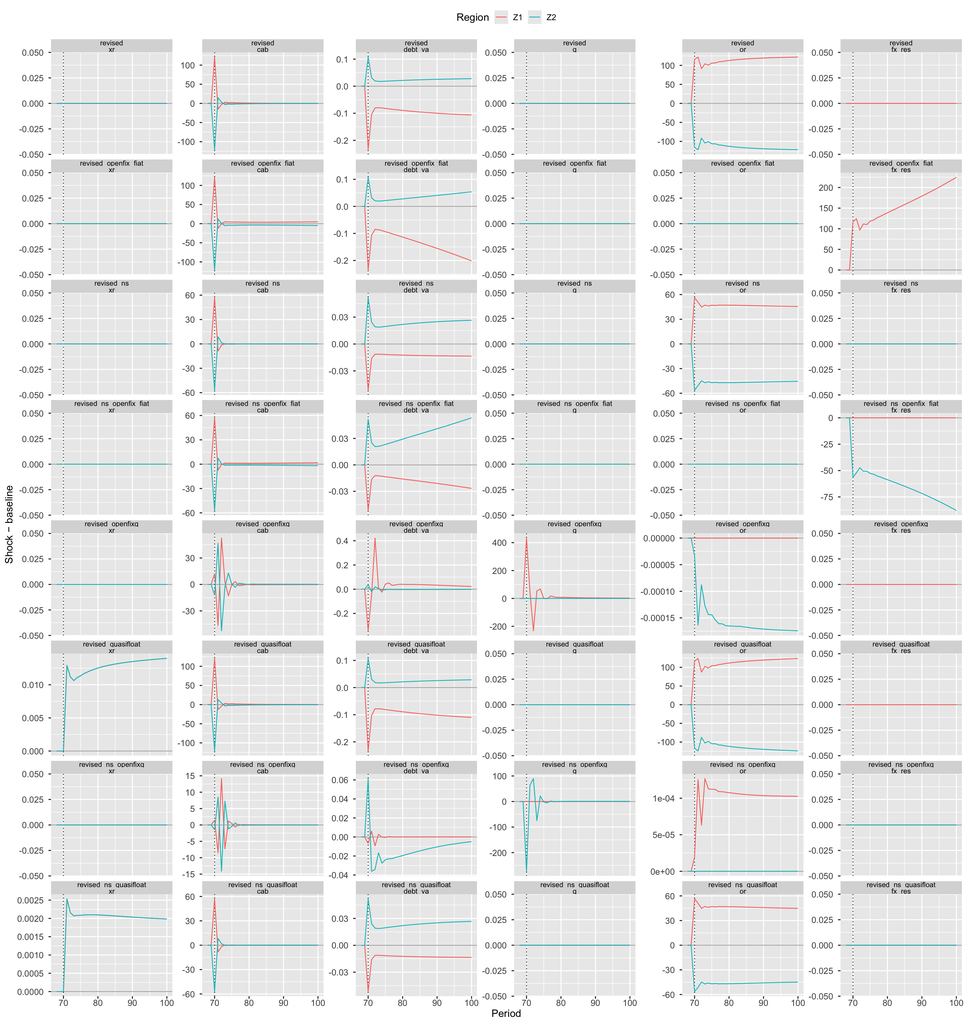

Source: output/calibration/closure_impulse_20261001.csv. Each line is shock minus the matching arm baseline, t=68..100; panels have their own scale. Debt/VA is a ratio difference; xr is Z1 currency in Z2 units; CAB is a flow, g is real spending, gold is quantity, FX reserves are issuer-currency bills. NA reserves are omitted.

Source: output/calibration/closure_impulse_20261001.csv ; level/ratio differences at impact, next period, and end of horizon. No cross-variable normalisation.

|  | arm | region | variable | diff.70 | diff.71 | diff.100 |
| --- | --- | --- | --- | --- | --- | --- |
| 3 | revised | Z1 | xr | 0.000000 | 0.000000 | 0.000000 |
| 36 | revised | Z1 | cab | 121.106027 | -14.876958 | 0.120615 |
| 135 | revised | Z1 | g | 0.000000 | 0.000000 | 0.000000 |
| 201 | revised | Z1 | debt_va | -0.234731 | -0.104382 | -0.106380 |
| 234 | revised | Z1 | or | 116.072669 | 121.911928 | 121.895920 |
| 300 | revised | Z1 | fx_res | 0.000000 | 0.000000 | 0.000000 |
| 333 | revised | Z2 | xr | 0.000000 | 0.000000 | 0.000000 |
| 366 | revised | Z2 | cab | -121.106027 | 14.876958 | -0.120615 |
| 465 | revised | Z2 | g | 0.000000 | 0.000000 | 0.000000 |
| 531 | revised | Z2 | debt_va | 0.107646 | 0.031304 | 0.027846 |
| 564 | revised | Z2 | or | -116.072658 | -121.911936 | -121.895941 |
| 630 | revised | Z2 | fx_res | NA | NA | NA |
| 663 | revised_openfix_fiat | Z1 | xr | 0.000000 | 0.000000 | 0.000000 |
| 696 | revised_openfix_fiat | Z1 | cab | 121.216890 | -12.372400 | 4.881411 |
| 795 | revised_openfix_fiat | Z1 | g | 0.000000 | 0.000000 | 0.000000 |
| 861 | revised_openfix_fiat | Z1 | debt_va | -0.235242 | -0.106826 | -0.201547 |
| 894 | revised_openfix_fiat | Z1 | or | 0.000000 | 0.000000 | 0.000000 |
| 960 | revised_openfix_fiat | Z1 | fx_res | 116.197507 | 124.496814 | 224.731770 |
| 993 | revised_openfix_fiat | Z2 | xr | 0.000000 | 0.000000 | 0.000000 |
| 1026 | revised_openfix_fiat | Z2 | cab | -121.216890 | 12.372400 | -4.881411 |
| 1125 | revised_openfix_fiat | Z2 | g | 0.000000 | 0.000000 | 0.000000 |
| 1191 | revised_openfix_fiat | Z2 | debt_va | 0.107569 | 0.031945 | 0.053903 |
| 1224 | revised_openfix_fiat | Z2 | or | 0.000000 | 0.000000 | 0.000000 |
| 1290 | revised_openfix_fiat | Z2 | fx_res | NA | NA | NA |
| 1323 | revised_ns | Z1 | xr | 0.000000 | 0.000000 | 0.000000 |
| 1356 | revised_ns | Z1 | cab | 57.063456 | -8.653992 | -0.069167 |
| 1455 | revised_ns | Z1 | g | 0.000000 | 0.000000 | 0.000000 |
| 1521 | revised_ns | Z1 | debt_va | -0.051659 | -0.015980 | -0.013504 |
| 1554 | revised_ns | Z1 | or | 56.381648 | 50.840733 | 45.491991 |
| 1620 | revised_ns | Z1 | fx_res | 0.000000 | 0.000000 | 0.000000 |

[output cut: 66 more lines]

**Interpretation.** Under gold, a persistent stock displacement after the flow impulse subsides is consistent with a neutral level mode. Under fiat, the reserve displacement exposes the interest-bearing settlement channel. Under OPENFIXG, the spending adjustment is the external transmission channel. The quasi-float shows the exchange-rate response at the registry’s existing `par_xr`; its horizon does not establish global stability or choose that parameter. A finite impulse is not an infinitesimal eigenvector experiment, so its final-period response alone cannot identify a root.

## OPENFLEX is an unstable control, not a ready impulse cell

Source: output/calibration/openflex_theta_sigma_scan_20261001.csv . growth is the fitted slope of log|xr−1| on t from period 5 to the last solved period (at most 100); factor=exp(growth). xr columns are levels; NA is unsolved.

| theta | sigma | last | growth | factor | xr_t10 | xr_t100 |
| --- | --- | --- | --- | --- | --- | --- |
| 1.00 | 1.0 | 23 | 0.205429 | 1.228051 | 1.092132 | NA |
| 0.50 | 1.0 | 100 | 0.141323 | 1.151797 | 1.102302 | 19936.62 |
| 0.50 | 0.0 | 100 | 0.138014 | 1.147992 | 1.117492 | 12951.42 |
| 1.00 | 0.0 | 100 | 0.138014 | 1.147992 | 1.117492 | 12951.42 |
| 0.25 | 0.0 | 100 | 0.138014 | 1.147992 | 1.117492 | 12951.42 |
| 0.25 | 1.0 | 100 | 0.143898 | 1.154767 | 1.121043 | 24655.50 |
| 0.25 | 0.5 | 100 | 0.141880 | 1.152438 | 1.117507 | 18597.74 |
| 0.50 | 0.5 | 100 | 0.140887 | 1.151294 | 1.113520 | 17060.67 |
| 1.00 | 0.5 | 100 | 0.140351 | 1.150678 | 1.115082 | 16167.81 |

The scan contains no stable band. Its `growth` is a log slope; the multiplicative growth factor is its exponential, not one plus the slope. With portfolio sensitivity switched off, the repeated expectation-adaptation settings produce the same runaway, so expectations alone cannot explain it. The full-adaptation, full-sensitivity run ends early and must not be interpreted using uncomputed final columns. An impulse on such a drifting baseline would mix the impulse with the runaway.

## Limits and decisions left open

The unit-root and reserve-interest accounts above are equation-based expectations pending a consistent-manifold stability analysis. All stock differences depend on the baseline calibration and the stated finite horizon. The maintainer retains the decisions on `par_xr`, the South’s short fiat reserve, scenario 6, and recalibrating the canonical enterprise premium with Ξ. This report makes none of those choices.

**Sources:** the four CSVs named above; `data/arms.csv`; `R/closures/impulse_closure.R`; `R/closures/closure_baseline_stability.R`; `model/code/MVP_model_2026.R`; `log/trackers/closure_region.md`; `ai_context/04_OPEN_QUESTIONS.md` (closure decisions).